# Beyond the Summit Pro Series 9 Americas 11/5/21

Conner ‘Mathmagician10’ Chapman

# Introduction

Hey guys, I’m [Mathmagician10](https://www.twitch.tv/mathmagician10). I am an amateur caster who is looking to use my statistics degree for more than just my day job, so I created this team analysis in [R](https://www.rstudio.com/) with what feels like a million datasets from [DatDota](https://www.datdota.com/). HUGE thanks to Noxville, Bonk, and TinT for allowing this stats sheet to happen cause without DatDota allowing nice API, Bonk’s ideas and TinT’s support this would not be possible. I hope you guys enjoy what you read. I’m hoping this makes the draft stage a little more fun for you guys to watch since you could have a better idea of what is coming. I’ll take any and all suggestions/criticisms as I would love to know what I can do to be better. For today’s analysis, we have the **BTS Pro Series AM Series 9**

# Regional Statistics

These statistics were compiled from hero data accross all 7.30 and 7.29 unless specified otherwise.

## Top Picks

These are the highest picked heroes regardless of win rate.

| hero | total | winrate | role_type |
| --- | --- | --- | --- |
| Tidehunter | 298 | 51.34 | Support |
| Mars | 262 | 47.71 | Support |
| Monkey King | 253 | 56.92 | Core |
| Void Spirit | 244 | 53.69 | Core |
| Pangolier | 233 | 45.06 | Support |
| Bane | 225 | 59.11 | Support |
| Lion | 221 | 49.32 | Support |
| Lina | 218 | 51.83 | Core |
| Tiny | 210 | 59.05 | Core |
| Sven | 194 | 50.52 | Core |

Draft Data by Selected Teams

| hero | picks | wins | pick_win_pct | top_phase |
| --- | --- | --- | --- | --- |
| Tiny | 36 | 25 | 69.44 | 1st Phase |
| Timbersaw | 28 | 15 | 53.57 | 1st Phase |
| Lion | 26 | 14 | 53.85 | 1st Phase |
| Abaddon | 24 | 12 | 50.00 | 3rd Phase |
| Centaur Warrunner | 24 | 16 | 66.67 | 1st Phase |
| Mars | 24 | 16 | 66.67 | 1st Phase |
| Ancient Apparition | 23 | 13 | 56.52 | 1st Phase |
| Luna | 22 | 11 | 50.00 | 1st Phase |
| Nyx Assassin | 22 | 13 | 59.09 | 1st Phase |
| Mirana | 20 | 10 | 50.00 | 3rd Phase |

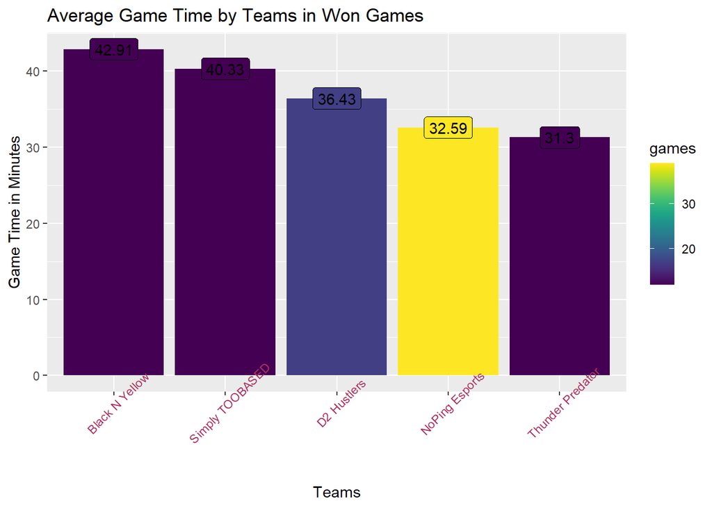

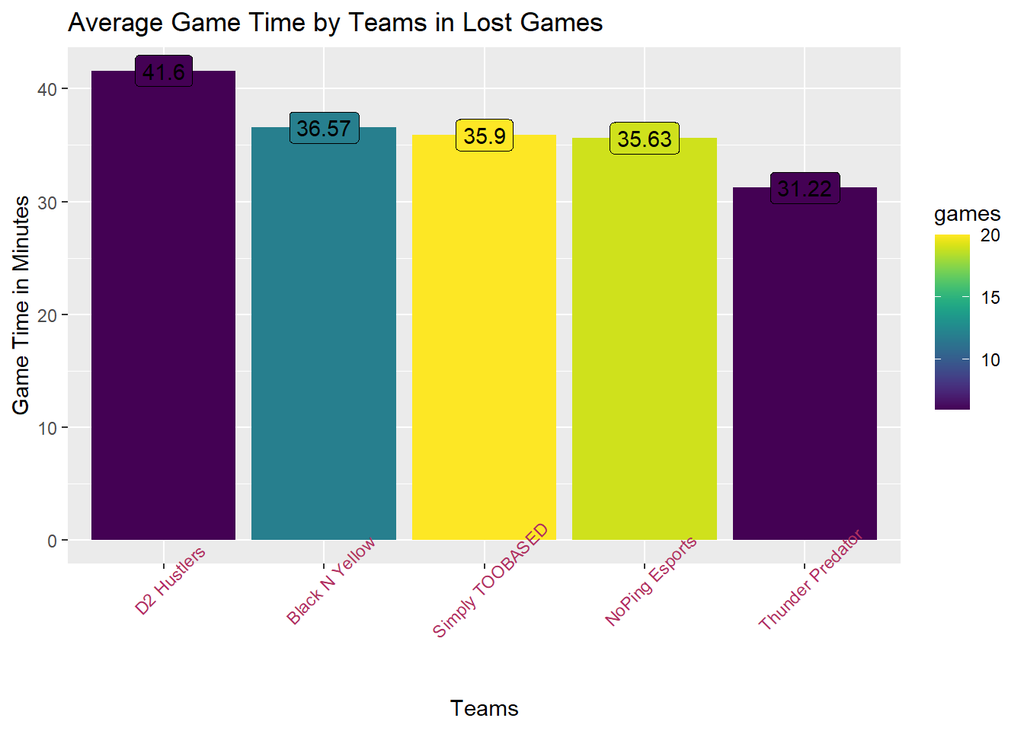

# Team Statistics BTS Pro Series AM Season 9

The following data will be for all phases of the draft. The goal will be to determine what the expected picks and bans will be solely based off of statistics, not necessarily previous games or previous pick/bans. Inherently, this makes the first phase draft data the most impactful as you will likely dedicate one of your first bans to taking away high priority heroes on the other team. Typically these are not in reaction to the other bans you would have already seen.

[figure not shown]

## D2 Hustlers

| hero | picks | top_phase | role_type | pick_win_pct | winrate | winrate_delta |
| --- | --- | --- | --- | --- | --- | --- |
| Invoker | 9 | 1st Phase | Core | 88.89 | 41.84 | 47.05 |
| Puck | 6 | 1st Phase | Core | 66.67 | 48.75 | 17.92 |
| Dragon Knight | 5 | 1st Phase | Core | 60.00 | 37.25 | 22.75 |
| Witch Doctor | 5 | 1st Phase | Support | 80.00 | 45.83 | 34.17 |
| Ancient Apparition | 4 | 1st Phase | Support | 100.00 | 60.53 | 39.47 |
| Centaur Warrunner | 4 | 1st Phase | Support | 75.00 | 47.37 | 27.63 |
| Magnus | 3 | 1st Phase | Core | 66.67 | 51.52 | 15.15 |
| Snapfire | 3 | 1st Phase | Support | 100.00 | 51.88 | 48.12 |
| Terrorblade | 3 | 1st Phase | Core | 100.00 | 50.50 | 49.50 |
| Axe | 2 | 1st Phase | Support | 0.00 | 46.43 | -46.43 |

| hero | name | total | winrate | kills | deaths | assists |
| --- | --- | --- | --- | --- | --- | --- |
| Invoker | Papatooty | 9 | 88.89 | 9.1 | 2.7 | 16.1 |
| Puck | Papatooty | 6 | 66.67 | 6.2 | 3.7 | 17.5 |
| Witch Doctor | Pandaego | 5 | 80.00 | 7.4 | 6.2 | 21.6 |
| Juggernaut | Yuma | 4 | 75.00 | 10.5 | 1.5 | 11.5 |
| Dragon Knight | 1437 | 4 | 75.00 | 3.8 | 5.5 | 19.0 |
| Ancient Apparition | Pandaego | 4 | 100.00 | 2.2 | 4.8 | 17.2 |
| Centaur Warrunner | Davai Lama | 4 | 75.00 | 4.5 | 5.2 | 21.0 |
| Timbersaw | Davai Lama | 4 | 50.00 | 13.8 | 4.5 | 12.2 |
| Abaddon | Pandaego | 4 | 50.00 | 2.0 | 4.8 | 10.2 |
| Void Spirit | Papatooty | 4 | 75.00 | 6.8 | 4.0 | 16.5 |

[figure not shown]

## Black n Yellow

| hero | picks | top_phase | role_type | pick_win_pct | winrate | winrate_delta |
| --- | --- | --- | --- | --- | --- | --- |
| Lion | 9 | 1st Phase | Support | 33.33 | 49.32 | -15.99 |
| Nyx Assassin | 9 | 1st Phase | Support | 55.56 | 47.83 | 7.73 |
| Ancient Apparition | 7 | 1st Phase | Support | 57.14 | 60.53 | -3.39 |
| Mirana | 4 | 1st Phase | Support | 75.00 | 56.02 | 18.98 |
| Timbersaw | 4 | 1st Phase | Core | 75.00 | 32.08 | 42.92 |
| Void Spirit | 4 | 1st Phase | Core | 25.00 | 53.69 | -28.69 |
| Dragon Knight | 3 | 1st Phase | Core | 100.00 | 37.25 | 62.75 |
| Viper | 3 | 1st Phase | Core | 33.33 | 51.02 | -17.69 |
| Warlock | 2 | 1st Phase | Support | 50.00 | 50.00 | 0.00 |
| Beastmaster | 1 | 1st Phase | Support | 100.00 | 59.69 | 40.31 |

| hero | name | total | winrate | kills | deaths | assists |
| --- | --- | --- | --- | --- | --- | --- |
| Lion | YamSun | 7 | 28.57 | 2.7 | 8.0 | 8.4 |
| Ancient Apparition | Jubei | 7 | 57.14 | 3.3 | 6.4 | 19.4 |
| Nyx Assassin | YamSun | 5 | 80.00 | 1.8 | 7.6 | 13.0 |
| Storm Spirit | esK | 4 | 50.00 | 10.0 | 3.0 | 11.8 |
| Faceless Void | EternaLEnVy | 4 | 50.00 | 5.0 | 4.2 | 8.5 |
| Nyx Assassin | FLee | 4 | 25.00 | 3.0 | 8.0 | 10.2 |
| Timbersaw | Zero | 4 | 75.00 | 9.5 | 3.5 | 11.2 |
| Mirana | FLee | 3 | 100.00 | 5.7 | 3.3 | 26.0 |
| Puck | esK | 3 | 66.67 | 9.3 | 3.3 | 12.7 |
| Sven | EternaLEnVy | 3 | 66.67 | 6.3 | 3.3 | 8.0 |

[figure not shown]

## Lava Lava

| hero | picks | top_phase | role_type | pick_win_pct | winrate | winrate_delta |
| --- | --- | --- | --- | --- | --- | --- |
| Tiny | 21 | 1st Phase | Core | 80.95 | 59.05 | 21.90 |
| Mars | 13 | 1st Phase | Support | 61.54 | 47.71 | 13.83 |
| Timbersaw | 12 | 1st Phase | Core | 66.67 | 32.08 | 34.59 |
| Viper | 12 | 1st Phase | Core | 75.00 | 51.02 | 23.98 |
| Centaur Warrunner | 11 | 1st Phase | Support | 81.82 | 47.37 | 34.45 |
| Winter Wyvern | 11 | 1st Phase | Support | 81.82 | 54.29 | 27.53 |
| Hoodwink | 10 | 1st Phase | Support | 50.00 | 32.20 | 17.80 |
| Nyx Assassin | 8 | 1st Phase | Support | 62.50 | 47.83 | 14.67 |
| Luna | 7 | 1st Phase | Core | 42.86 | 43.65 | -0.79 |
| Terrorblade | 4 | 1st Phase | Core | 100.00 | 50.50 | 49.50 |

[output not shown]

[figure not shown]

## Thunder Predator

| hero | picks | top_phase | role_type | pick_win_pct | winrate | winrate_delta |
| --- | --- | --- | --- | --- | --- | --- |
| Mars | 5 | 1st Phase | Support | 100.00 | 47.71 | 52.29 |
| Phoenix | 5 | 1st Phase | Support | 80.00 | 37.23 | 42.77 |
| Puck | 5 | 1st Phase | Core | 80.00 | 48.75 | 31.25 |
| Tiny | 4 | 1st Phase | Core | 50.00 | 59.05 | -9.05 |
| Centaur Warrunner | 3 | 1st Phase | Support | 66.67 | 47.37 | 19.30 |
| Earth Spirit | 3 | 1st Phase | Support | 33.33 | 48.94 | -15.61 |
| Viper | 3 | 1st Phase | Core | 33.33 | 51.02 | -17.69 |
| Beastmaster | 2 | 1st Phase | Support | 100.00 | 59.69 | 40.31 |
| Death Prophet | 2 | 1st Phase | Core | 0.00 | 40.62 | -40.62 |
| Lina | 2 | 1st Phase | Core | 100.00 | 51.83 | 48.17 |

[output not shown]

[figure not shown]

## Simply TOOBASED

| hero | picks | top_phase | role_type | pick_win_pct | winrate | winrate_delta |
| --- | --- | --- | --- | --- | --- | --- |
| Luna | 9 | 1st Phase | Core | 55.56 | 43.65 | 11.91 |
| Ancient Apparition | 7 | 1st Phase | Support | 42.86 | 60.53 | -17.67 |
| Mirana | 7 | 1st Phase | Support | 0.00 | 56.02 | -56.02 |
| Timbersaw | 7 | 1st Phase | Core | 28.57 | 32.08 | -3.51 |
| Tiny | 7 | 1st Phase | Core | 42.86 | 59.05 | -16.19 |
| Puck | 5 | 1st Phase | Core | 60.00 | 48.75 | 11.25 |
| Snapfire | 5 | 1st Phase | Support | 80.00 | 51.88 | 28.12 |
| Centaur Warrunner | 4 | 1st Phase | Support | 50.00 | 47.37 | 2.63 |
| Earth Spirit | 4 | 1st Phase | Support | 50.00 | 48.94 | 1.06 |
| Phoenix | 4 | 1st Phase | Support | 50.00 | 37.23 | 12.77 |

| hero | name | total | winrate | kills | deaths | assists |
| --- | --- | --- | --- | --- | --- | --- |
| Luna | Boris | 9 | 55.56 | 8.1 | 3.7 | 8.6 |
| Ancient Apparition | empyreaN | 7 | 42.86 | 1.6 | 8.4 | 13.4 |
| Puck | IAnnihilate | 5 | 60.00 | 7.0 | 2.0 | 13.4 |
| Tiny | IAnnihilate | 5 | 20.00 | 7.0 | 2.8 | 6.2 |
| Death Prophet | Monkeys-forever | 5 | 60.00 | 4.6 | 4.6 | 9.0 |
| Timbersaw | Monkeys-forever | 5 | 40.00 | 6.0 | 4.2 | 8.2 |
| Snapfire | empyreaN | 5 | 80.00 | 2.2 | 4.8 | 13.2 |
| Storm Spirit | IAnnihilate | 4 | 25.00 | 5.2 | 4.8 | 7.2 |
| Gyrocopter | Boris | 4 | 50.00 | 7.8 | 5.0 | 6.2 |
| Centaur Warrunner | Monkeys-forever | 4 | 50.00 | 1.2 | 5.8 | 12.2 |